# Support Vector Machines (SVM) — Supplemental Slides

Bill Cresko

# Support Vector Machines (SVM)

## What are Support Vector Machines?

SVMs find the optimal **hyperplane** (decision boundary) that separates classes with the **maximum margin**.

- **Hyperplane**: Decision boundary that separates classes
- **Support Vectors**: Data points closest to the hyperplane (the critical observations)
- **Margin**: Distance between the hyperplane and the nearest points
- **Maximum Margin**: SVM finds the hyperplane with the largest margin

## Mathematical Foundation

- Equation
- LaTeX
- Parameters

Minimize:
$$\frac{1}{2}||w||^2 + C\sum_{i=1}^{n}\xi_i$$

Subject to: $y_i(w^T x_i + b) \geq 1 - \xi_i$ and $\xi_i \geq 0$

```
\min \frac{1}{2}||w||^2 + C\sum_{i=1}^{n}\xi_i

\text{s.t. } y_i(w^T x_i + b) \geq 1 - \xi_i, \quad \xi_i \geq 0
```

- $w$: weight vector (defines hyperplane orientation)
- $b$: bias term
- $C$: regularization parameter (tradeoff between margin width and misclassification)
- $\xi_i$: slack variables (allow some misclassification for soft-margin SVM)

## The Kernel Trick

**Problem**: What if data is not linearly separable?

**Solution**: Map data to a higher-dimensional space using **kernel functions** where it becomes linearly separable.

**Popular Kernels:**

- **Linear**: $K(x_i, x_j) = x_i^T x_j$
- **Polynomial**: $K(x_i, x_j) = (x_i^T x_j + 1)^d$
- **RBF (Radial Basis Function)**: $K(x_i, x_j) = \exp(-\gamma ||x_i - x_j||^2)$

## Kernel Trick Visualization

[figure not shown]

The kernel trick maps data to a higher-dimensional space where it becomes linearly separable.

## SVM in R: Nanoparticle Classification

- Code
- Hyperparameter Tuning

```r
library(e1071)

# Use same train/test split from KNN
set.seed(2026)
train_idx <- sample(nrow(np_data), 0.7 * nrow(np_data))
train_np <- np_data[train_idx, ]
test_np  <- np_data[-train_idx, ]

# Build RBF SVM
svm_rbf <- svm(uptake_class ~ size + zeta_potential + peg_density +
                 drug_loading + pdi,
               data = train_np, kernel = "radial",
               cost = 10, gamma = 0.1)

# Predictions and accuracy
svm_pred <- predict(svm_rbf, test_np)
cat("SVM Accuracy:", mean(svm_pred == test_np$uptake_class))
table(Predicted = svm_pred, Actual = test_np$uptake_class)
```

```r
# Grid search for optimal cost and gamma
tune_result <- tune(svm,
                    uptake_class ~ size + zeta_potential + peg_density +
                      drug_loading + pdi,
                    data = train_np, kernel = "radial",
                    ranges = list(
                      cost = c(0.1, 1, 10, 100),
                      gamma = c(0.01, 0.1, 1, 10)
                    ))

print(tune_result$best.parameters)
cat("Best accuracy:", 1 - tune_result$best.performance)
```

## SVM vs Other Algorithms

| Algorithm | Best For | Pros | Cons |
| --- | --- | --- | --- |
| **SVM** | High-dim, small-medium data | Robust, versatile kernels | Slow on large data |
| **Random Forest** | General purpose, large data | Fast, interpretable | Can overfit |
| **KNN** | Small datasets | Simple, no training | Slow at prediction |

## SVM Decision Boundaries by Kernel

- Output
- Code
- Takeaway

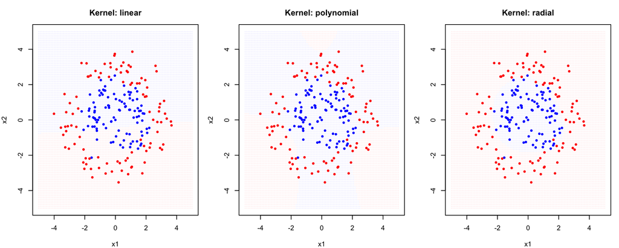

```r
library(e1071)

# Create grid for visualization
grid <- expand.grid(
  x1 = seq(-5, 5, length.out = 100),
  x2 = seq(-5, 5, length.out = 100)
)

par(mfrow = c(1, 3))
for (kern in c("linear", "polynomial", "radial")) {
  fit <- svm(class ~ x1 + x2, data = svm_data,
             kernel = kern, cost = 10, gamma = 0.5)
  pred <- predict(fit, grid)

  plot(grid$x1, grid$x2,
       col = ifelse(pred == "A",
             rgb(0.7, 0.7, 1, 0.2), rgb(1, 0.7, 0.7, 0.2)),
       pch = 15, cex = 0.3, main = paste("Kernel:", kern),
       xlab = "x1", ylab = "x2")
  points(svm_data$x1, svm_data$x2,
         col = ifelse(svm_data$class == "A", "blue", "red"),
         pch = 19, cex = 0.6)
}
```

## Nanoparticle Drug Delivery Dataset

**Study Description**

A drug delivery lab characterized 300 polymeric nanoparticles for targeted cancer therapy. Each nanoparticle was measured for size, surface charge (zeta potential), PEG coating density, drug loading efficiency, and polydispersity index. Based on in vitro cellular uptake assays, each formulation was classified as low, medium, or high uptake.

| Variable | Type | Description | Units / Levels |
| --- | --- | --- | --- |
| `size` | Continuous | Mean hydrodynamic diameter | nm |
| `zeta_potential` | Continuous | Surface charge | mV |
| `peg_density` | Continuous | PEG surface coating density | chains/nm² |
| `drug_loading` | Continuous | Drug encapsulation efficiency | % |
| `pdi` | Continuous | Polydispersity index | 0–1 |
| `uptake_class` | Categorical | Cellular uptake classification | low / medium / high |

```r
np_data <- read_csv("data/nanoparticle_delivery.csv")
np_data$uptake_class <- factor(np_data$uptake_class, levels = c("low", "medium", "high"))
glimpse(np_data)
```

## R Exercise: SVM Classification

**Exercise**

1. Load the nanoparticle dataset and split 70/30 train/test
2. Fit a **linear SVM** and an **RBF SVM** to predict uptake class
3. Use `tune()` to find optimal cost and gamma for the RBF kernel
4. Compare test-set accuracy for both kernels
5. How does SVM compare to random forest on this dataset?